# **Introduction to my Data Analysis Project**

In this Research Project I would like to explore data related to Netflix and its Movies and TV Shows.

The reason why I chose this dataset was because I've always been an avid fan of film and one problem that I had with Netflix is that it's search function is not that helpful and I wanted a way to figure out new movies and tv shows that I could watch in the future based on specific parameters such as genre, duration, release-date and director/cast.

My taste in film often changes based on what mood I'm in and so one question that I would like to investigate is **how many genres Netflix has and which genre dominates the platform.**

Another question that I wanted to investigate regards the spread of film durations. My choice of film often involves the length of the film as I usually like to watch short tv shows during exam season and longer movies on weekends when I don't have work. **Therefore one question I have is what is the average film duration for tv shows and movies on Netflix?**

Release date is also an interesting parameter to explore. For example, does Netflix own rights to older movies especially since a lot of these older movies are owned by big corporations and may not allow for Netflix to get the rights to play these films. **What time period are most of the films on Netflix from?**

Last but not least, I would like to be able to sort films based on director and cast. I've been recently seeing a lot more Asian films in the last year and I was wondering if Netflix's choice in including more modern Asian films would mean that there are a lot more films directed and casted by Asians. **Who are the International (non-US) directors/cast with most films on Netflix?**

These are just some of the basic questions that I will exploring in this project.

## **First Part: Data Cleaning and Data Checks**

Let us first take a look at what type of data that this dataset. The dataset used is included in the google drive folder. The csv file itself is called netflix_tites.

Link to original dataset: https://www.kaggle.com/shivamb/netflix-shows

This data was collected by Shivam Bansal on Kaggle.

**Import Libraries:**

```python
import numpy as np # linear algebra
import pandas as pd # data processing, CSV file I/O (e.g. pd.read_csv)
import matplotlib.pyplot as plt
import seaborn as sns
import itertools
from collections import Counter
from google.colab import drive
drive.mount('/content/gdrive')
df_netflix = pd.read_csv('/content/gdrive/My Drive/Data Science/netflix_titles.csv')
pd.set_option("display.max.columns", None)
```

Let's take a look at the Data's information including its columns. From below we can see that there are **7787** different titles included in the dataset. The data that we have been provided include the show's id (not that useful), type, title, director, cast, country, date_added (not as useful), release_year, rating, duration, listed_in (genre) and description. In the project I will be focusing on sorting based on **title**, **director**, **cast**, **country**, **release_year**, **rating**, **duration** and **listed_in**. As shown by the column's type, only the release year is included as an integer, the rest is included as a string or object.

```python
df_netflix.info()
#df_netflix.describe() use later for release year data
```

```
<class 'pandas.core.frame.DataFrame'>
RangeIndex: 7787 entries, 0 to 7786
Data columns (total 12 columns):
 #   Column        Non-Null Count  Dtype
---  ------        --------------  -----
 0   show_id       7787 non-null   object
 1   type          7787 non-null   object
 2   title         7787 non-null   object
 3   director      5398 non-null   object
 4   cast          7069 non-null   object
 5   country       7280 non-null   object
 6   date_added    7777 non-null   object
 7   release_year  7787 non-null   int64
 8   rating        7780 non-null   object
 9   duration      7787 non-null   object
 10  listed_in     7787 non-null   object
 11  description   7787 non-null   object
dtypes: int64(1), object(11)
memory usage: 730.2+ KB
```

```python
df_netflix.shape
```

```
(7787, 12)
```

```python
df_netflix.dtypes
```

```
show_id         object
type            object
title           object
director        object
cast            object
country         object
date_added      object
release_year     int64
rating          object
duration        object
listed_in       object
description     object
dtype: object
```

Next, lets look at the datasets shape and structure. We will also take a clearer look at what data each column actually represents and their distribution.

As can be seen below, not every column has an equal count showing that there is not data present for each row. However, we can see that every title has an id, type and title as there are 7787 of each of them.

There are not that many notable data quality issues. The number of titles with no director is a little concerning but other than that, most of the data seem very clean and have at least 7000 different inputs.

We can also see some interesting facts such as that David Attenborough is the top cast member and Raul Campos and Jan Suter are the top directors. Unexpectedly, United States is the top location that the films were produced in.

There are some surprising things about this data. The duration for tv shows may be a little difficult to understand as they are given by how many seasons they have instead of total duration or average episode duration. Also one thing to note is that there are multiple director and cast members listed for each title and we might have to take some time to parse them into individual people.

```python
df_netflix.isnull().sum()
```

```
show_id            0
type               0
title              0
director        2389
cast             718
country          507
date_added        10
release_year       0
rating             7
duration           0
listed_in          0
description        0
dtype: int64
```

```python
df_netflix.describe(include=np.object)
```

|  | show_id | type | title | director | cast | country | date_added | rating | duration | listed_in | description |
| --- | --- | --- | --- | --- | --- | --- | --- | --- | --- | --- | --- |
| count | 7787 | 7787 | 7787 | 5398 | 7069 | 7280 | 7777 | 7780 | 7787 | 7787 | 7787 |
| unique | 7787 | 2 | 7787 | 4049 | 6831 | 681 | 1565 | 14 | 216 | 492 | 7769 |
| top | s1996 | Movie | The Last Face | Raúl Campos, Jan Suter | David Attenborough | United States | January 1, 2020 | TV-MA | 1 Season | Documentaries | Multiple women report their husbands as missin... |
| freq | 1 | 5377 | 1 | 18 | 18 | 2555 | 118 | 2863 | 1608 | 334 | 3 |

Now that we know what this data includes, we can clean the data by removing columns we don't need. We will sort individual column data later when we get to the Data Exploration and Visualization part.

```python
df_netflix = df_netflix.drop(['show_id','description'], axis=1)
df_netflix.head()
```

|  | type | title | director | cast | country | date_added | release_year | rating | duration | listed_in |
| --- | --- | --- | --- | --- | --- | --- | --- | --- | --- | --- |
| 0 | TV Show | 3% | NaN | João Miguel, Bianca Comparato, Michel Gomes, R... | Brazil | August 14, 2020 | 2020 | TV-MA | 4 Seasons | International TV Shows, TV Dramas, TV Sci-Fi &... |
| 1 | Movie | 7:19 | Jorge Michel Grau | Demián Bichir, Héctor Bonilla, Oscar Serrano, ... | Mexico | December 23, 2016 | 2016 | TV-MA | 93 min | Dramas, International Movies |
| 2 | Movie | 23:59 | Gilbert Chan | Tedd Chan, Stella Chung, Henley Hii, Lawrence ... | Singapore | December 20, 2018 | 2011 | R | 78 min | Horror Movies, International Movies |
| 3 | Movie | 9 | Shane Acker | Elijah Wood, John C. Reilly, Jennifer Connelly... | United States | November 16, 2017 | 2009 | PG-13 | 80 min | Action & Adventure, Independent Movies, Sci-Fi... |
| 4 | Movie | 21 | Robert Luketic | Jim Sturgess, Kevin Spacey, Kate Bosworth, Aar... | United States | January 1, 2020 | 2008 | PG-13 | 123 min | Dramas |

## **Second Part: Data Exploration and Visualization**

### 1. Type of Netflix Titles

Let's look at what the Netflix titles are categorised by in regards to type.

Since the two types of data that type includes are "Movie" and "TV Show" we can sort the larger netflix dataframe into two separate dataframes for each type.

```python
df_netflix.type.value_counts

TVshows = df_netflix[df_netflix['type'] == 'TV Show']
Movie = df_netflix[df_netflix['type'] == 'Movie']

df_netflix.type.unique()
```

```
array(['TV Show', 'Movie'], dtype=object)
```

Let's take a look at the number of TV shows vs the number of Movies on Netflix.

As can we see from below there are way more Movies than TV shows. This makes sense as the TV show industry started later than the Film industry and there are probably more films out there that Netflix can get copyrights for.

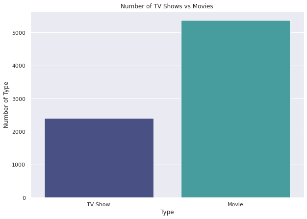

```python
plt.figure(figsize=(10,7))
sns.set(style="darkgrid")
ax = sns.countplot(x="type", data=df_netflix, palette="mako")
ax.set(xlabel='Type', ylabel='Number of Type')
plt.title("Number of TV Shows vs Movies")
```

### 2. Analysis on Release Dates

Let's take a look at the data we were given regarding release dates for the movies and tv-shows.

As it is the only numerical data we got, we can take a more quanitative look at the data.

```python
print(df_netflix.release_year)
```

```
0       2020
1       2016
2       2011
3       2009
4       2008
        ...
7782    2005
7783    2015
7784    2019
7785    2019
7786    2019
Name: release_year, Length: 7787, dtype: int64
```

```python
df_netflix.describe()
```

|  | release_year |
| --- | --- |
| count | 7787.000000 |
| mean | 2013.932580 |
| std | 8.757395 |
| min | 1925.000000 |
| 25% | 2013.000000 |
| 50% | 2017.000000 |
| 75% | 2018.000000 |
| max | 2021.000000 |

Below is a boxplot and histogram of the data. It is apparent that most of the releases are concentrated in the 10 year period from 2010-2020.

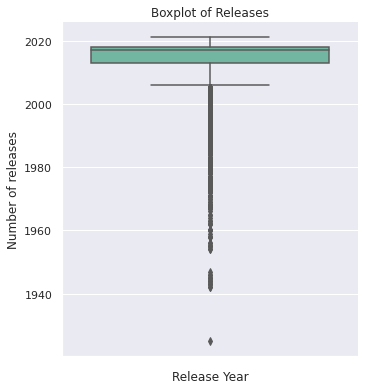

```python
number_of_releases = df_netflix['release_year'].value_counts()
plt.figure(figsize=(30,50))
bx = sns.catplot(y='release_year', data=df_netflix, palette="Set2", kind="box")
bx.set(xlabel='Release Year', ylabel='Number of releases')
plt.title("Boxplot of Releases")
```

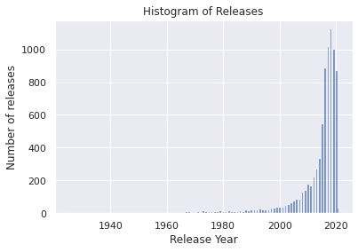

```python
bx = sns.histplot(x='release_year', data=df_netflix, palette="Set2")
bx.set(xlabel='Release Year', ylabel='Number of releases')
plt.title("Histogram of Releases")
```

The bar chart below gives us a better idea of the years with the most releases. It is unsuprising that the top 5 comprise of the last 5 years.

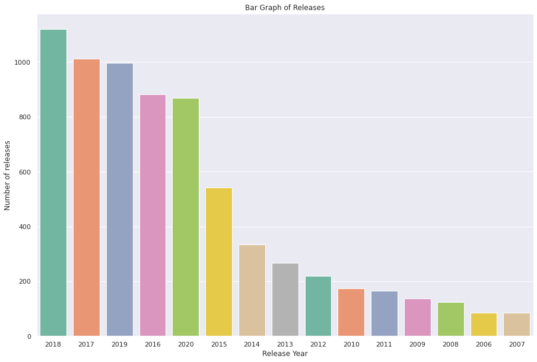

```python
plt.figure(figsize=(15,10))
ax = sns.countplot(x='release_year', data=df_netflix, palette="Set2", order=number_of_releases.index[0:15])
ax.set(xlabel='Release Year', ylabel='Number of releases')
plt.title("Bar Graph of Releases")
```

### 3. Release Dates in regards to COVID

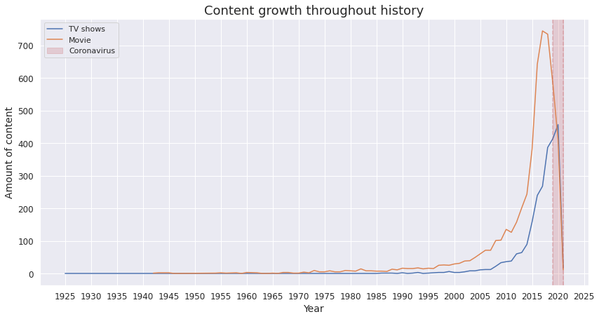

```python
TVshows_progress = TVshows['release_year'].value_counts().sort_index()

Movie_progress = Movie['release_year'].value_counts().sort_index()
plt.figure(figsize=(14, 7))

plt.plot(TVshows_progress.index, TVshows_progress.values, label='TV shows')
plt.plot(Movie_progress.index, Movie_progress.values, label='Movie')
#plt.plot(df_netflix['release_year'].index, df_netflix['release_year'].values, label='Total')

plt.axvline(2019, alpha=0.3, linestyle='--', color='r')
plt.axvline(2021, alpha=0.3, linestyle='--', color='r')
plt.axvspan(2019, 2021, alpha=0.2, color='r', label='Coronavirus')

plt.xticks(list(range(1925, 2026, 5)), fontsize=12)
plt.title('Content growth throughout history', fontsize=18)
plt.xlabel('Year', fontsize=14)
plt.ylabel('Amount of content', fontsize=14)
plt.yticks(fontsize=12)
plt.legend()
plt.show()
```

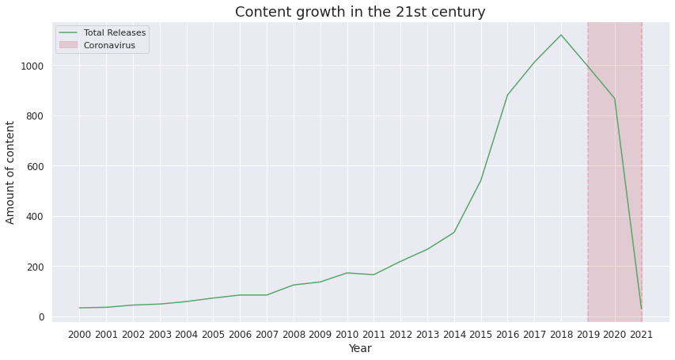

```python
df_netflix2 = df_netflix[df_netflix.release_year>=2000]
Total_progress = df_netflix2['release_year'].value_counts().sort_index()

plt.figure(figsize=(14, 7))
plt.plot(Total_progress.index, Total_progress.values, label='Total Releases', color='g')

plt.axvline(2019, alpha=0.3, linestyle='--', color='r')
plt.axvline(2021, alpha=0.3, linestyle='--', color='r')
plt.axvspan(2019, 2021, alpha=0.2, color='r', label='Coronavirus')

plt.xticks(list(range(2000, 2022, 1)), fontsize=12)
plt.title('Content growth in the 21st century', fontsize=18)
plt.xlabel('Year', fontsize=14)
plt.ylabel('Amount of content', fontsize=14)
plt.yticks(fontsize=12)
plt.legend()
plt.show()
```

### 4. Country Analysis

The bar charts below show the countries with the highest number of movie and tv show releases. It is interesting that India is second in the list, highlighting the rise of Bollywood and Netflix's decision to include more Indian films on its platform (perhaps to increase viewers from Asian communities).

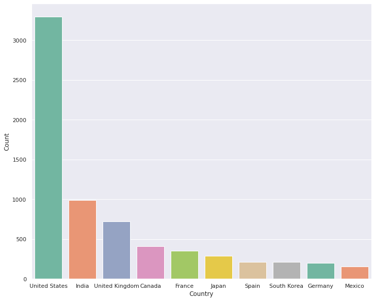

```python
# print(df_netflix.columns)
# country=pd.Series(df_netflix.country)
# print(pd.unique(country))
list_country = [x.split(', ') for x in df_netflix.dropna(subset=['country'])['country'].tolist()]
list_country = list(itertools.chain(*list_country))

df_netflix_country_count = pd.DataFrame(Counter(list_country).most_common()[:10], columns=['Country', 'Count'])
plt.figure(figsize=(12,10))
sns.set(style="darkgrid")
ax = sns.barplot(y="Count", x='Country', data=df_netflix_country_count, palette="Set2", orient='v')
```

There are a total of 120 countries in the dataset. However, each movie and TV show is given multiple countries and hence inflates the score of countries with a lot of capital in film production such as the United States.

```
Number of different countries: 120
```

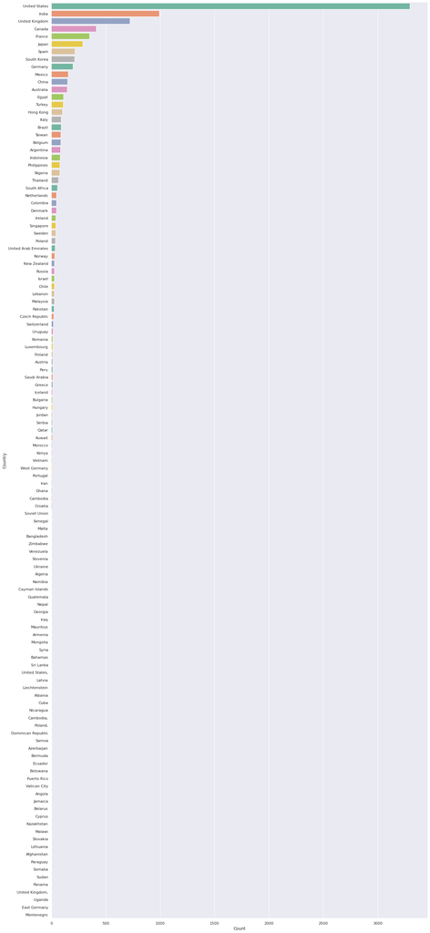

```python
df_netflix_country_count = pd.DataFrame(Counter(list_country).most_common()[:], columns=['Country', 'Count'])
print("Number of different countries:",len(df_netflix_country_count)-1)
print()
plt.figure(figsize=(20,50))
sns.set(style="darkgrid")
ax = sns.barplot(x="Count", y='Country', data=df_netflix_country_count, palette="Set2", orient='h')
```

### 5. Rating

The bar charts below show the contnet rating for both movies and TV-shows. It is interesting that Movies have a lot more R-rated films. Perhaps this is because TV channels would not allow for R-rated films to be placed on their platform.

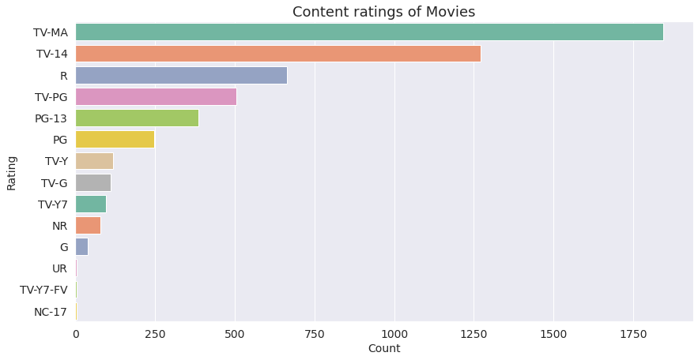

```python
rating = Movie['rating'].value_counts()

plt.figure(figsize=(14,7))
plt.title('Content ratings of Movies', fontsize=18)
plt.tick_params(labelsize=14)
sns.barplot(y=rating.index, x=rating.values, palette="Set2")
plt.xlabel('Count', fontsize=14)
plt.ylabel('Rating', fontsize=14)

plt.show()
```

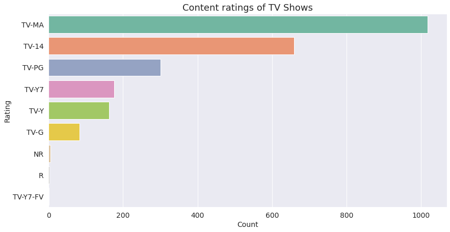

```python
rating = TVshows['rating'].value_counts()

plt.figure(figsize=(14,7))
plt.title('Content ratings of TV Shows', fontsize=18)
plt.tick_params(labelsize=14)
sns.barplot(y=rating.index, x=rating.values, palette="Set2")
plt.xlabel('Count', fontsize=14)
plt.ylabel('Rating', fontsize=14)

plt.show()
```

### 6a. Duration for Movies

Below, I have analysed the distribution of films based on their length. Due to the difference of data type for movies and TV shows, I have separated the data for the two different subcategories. Some highlights from the Movies data is that the mean duration was 99 minutes and the longest movie was a whooping 312 minutes long (however that movie is not really that long as it was an interactive film with multiple endings making it an outlier).

```
       release_year     duration
count   5377.000000  5377.000000
mean    2012.920030    99.307978
std        9.663282    28.530881
min     1942.000000     3.000000
25%     2012.000000    86.000000
50%     2016.000000    98.000000
75%     2018.000000   114.000000
max     2021.000000   312.000000
```

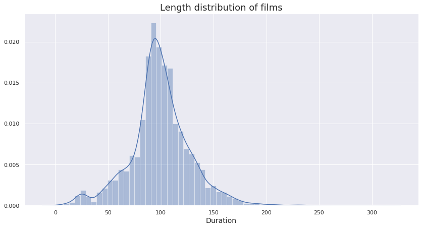

```python
import warnings
warnings.simplefilter(action='ignore', category=FutureWarning)
pd.options.mode.chained_assignment = None  # default='warn'

grp = df_netflix.groupby('type')
movie = grp.get_group('Movie')
movie['duration'] = [int(i.split(' ')[0]) for i in movie.duration.dropna()]

plt.figure(figsize=(14, 7))
print()
print(movie.describe())
sns.distplot(movie['duration'], bins=60).set(ylabel=None)

plt.title('Length distribution of films', fontsize=18)
plt.xlabel('Duration', fontsize=14)
plt.show()
```

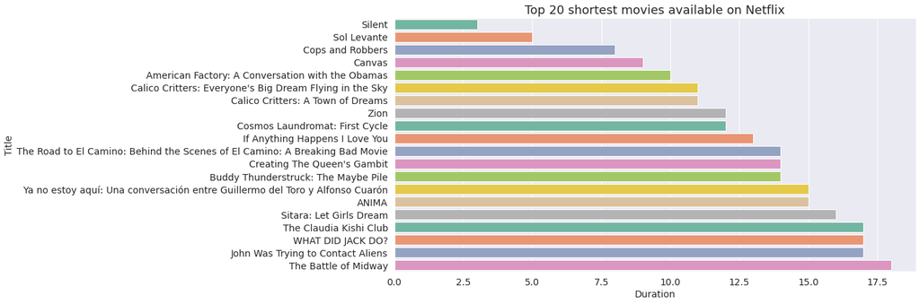

```python
short = movie.sort_values('duration')[['title', 'duration']].iloc[:20]

plt.figure(figsize=(14,7))
plt.title('Top 20 shortest movies available on Netflix', fontsize=18)
plt.tick_params(labelsize=14)
sns.barplot(y=short['title'], x=short['duration'], palette="Set2")
plt.xlabel('Duration', fontsize=14)
plt.ylabel('Title', fontsize=14)
plt.show()
```

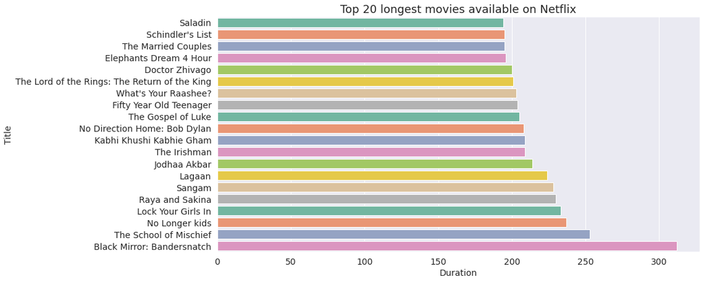

```python
long = movie.sort_values('duration')[['title', 'duration']].iloc[-20:]
#print(long)
plt.figure(figsize=(14,7))
plt.title('Top 20 longest movies available on Netflix', fontsize=18)
plt.tick_params(labelsize=14)
sns.barplot(y=long['title'], x=long['duration'], palette="Set2")
plt.xlabel('Duration', fontsize=14)
plt.ylabel('Title', fontsize=14)

plt.show()
```

### 6b. Duration for TV Shows

Unlike the movies, the TV shows have their duration data given by how many seasons. As expected most of the shows only have one season and this makes sense as most newer TV shows have not released all their seasons.

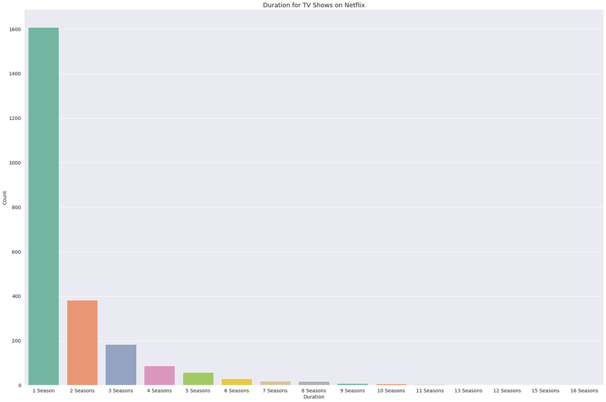

```python
list_TV_Show = [x.split(', ') for x in TVshows.dropna(subset=['duration'])['duration'].tolist()]
list_TV_Show = list(itertools.chain(*list_TV_Show))
df_netflix_tv_count = pd.DataFrame(Counter(list_TV_Show).most_common()[:],columns=['x', 'y'])
#print(df_netflix_tv_count)
labels = df_netflix_tv_count['x']
sizes = df_netflix_tv_count['y']
plt.figure(figsize=(30,20))
labels = df_netflix_tv_count.keys()
sns.barplot(x=df_netflix_tv_count['x'], y=df_netflix_tv_count['y'], palette="Set2")
plt.tick_params(labelsize=14)
plt.title('Duration for TV Shows on Netflix', fontsize=18)
plt.xlabel('Duration', fontsize=14)
plt.ylabel('Count', fontsize=14)
plt.show()
```

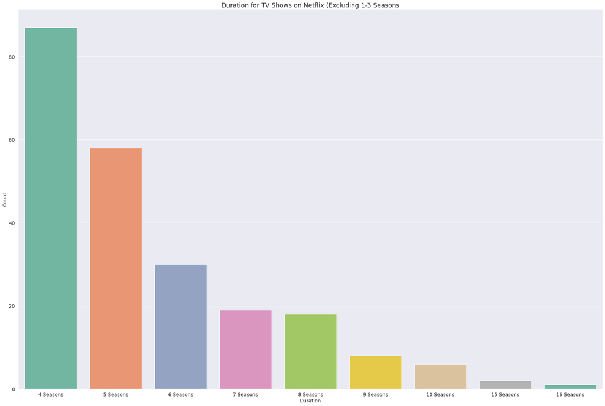

```python
list_TV_Show = [x.split(', ') for x in TVshows.dropna(subset=['duration'])['duration'].tolist()]
list_TV_Show = list(itertools.chain(*list_TV_Show))
df_netflix_tv_count = pd.DataFrame(Counter(list_TV_Show).most_common()[:],columns=['x', 'y'])
searchfor = ['1 Season', '2 Season', '3 Season']
df_netflix_tv_count = df_netflix_tv_count[~df_netflix_tv_count['x'].str.contains('|'.join(searchfor),na=False)]
#print(df_netflix_tv_count)
labels = df_netflix_tv_count['x']
sizes = df_netflix_tv_count['y']
plt.figure(figsize=(30,20))
labels = df_netflix_tv_count.keys()
sns.barplot(x=df_netflix_tv_count['x'], y=df_netflix_tv_count['y'], palette="Set2" )
plt.tick_params(labelsize=14)
plt.title('Duration for TV Shows on Netflix (Excluding 1-3 Seasons', fontsize=18)
plt.xlabel('Duration', fontsize=14)
plt.ylabel('Count', fontsize=14)
plt.show()
```

```
           x     y
0   1 Season  1608
1  2 Seasons   382
2  3 Seasons   184
3  4 Seasons    87
0      Other   149
```

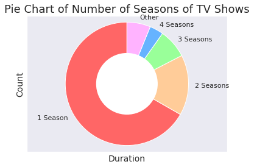

```python
list_TV_Show = [x.split(', ') for x in TVshows.dropna(subset=['duration'])['duration'].tolist()]
list_TV_Show = list(itertools.chain(*list_TV_Show))
df_netflix_tv_count = pd.DataFrame(Counter(list_TV_Show).most_common()[:],columns=['x', 'y'])
df_netflix_tv_count2 = pd.DataFrame(Counter(list_TV_Show).most_common()[:4],columns=['x', 'y'])
x = df_netflix_tv_count['y'].sum()-df_netflix_tv_count.iloc[0]['y']-df_netflix_tv_count.iloc[1]['y']-df_netflix_tv_count.iloc[2]['y']-df_netflix_tv_count.iloc[3]['y']
df = pd.DataFrame([['Other', x]],  columns=list('xy'))
df_netflix_tv_count2=df_netflix_tv_count2.append(df)
print(df_netflix_tv_count2)


labels = df_netflix_tv_count2['x']
sizes = df_netflix_tv_count2['y']


colors = ['#ff6666', '#ffcc99', '#99ff99', '#66b3ff','#ffb3ff']

# Plot
plt.pie(sizes, labels=labels, colors=colors, startangle=90,frame=True)
centre_circle = plt.Circle((0,0),0.5,color='black', fc='white',linewidth=0)
fig = plt.gcf()
fig.gca().add_artist(centre_circle)
plt.title('Pie Chart of Number of Seasons of TV Shows', fontsize=18)
plt.axis('equal')
plt.tight_layout()
plt.grid(False)
plt.xlabel('Duration', fontsize=14)
plt.ylabel('Count', fontsize=14)
plt.tick_params(top=False, bottom=False, left=False, right=False,
                labelleft=False, labelbottom=False)
plt.show()
```